# Juvenile snowshoe hares in Bonanza Creek: exploratory report

### Comparison of juvenile hare weights by sex and site

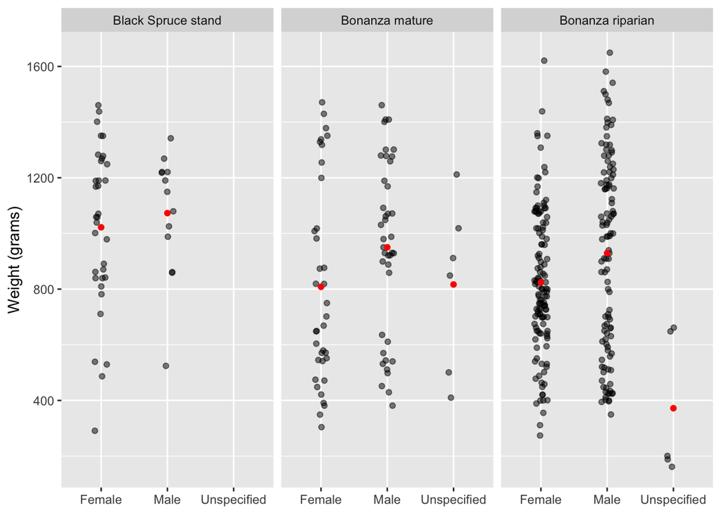

**Figure 2.** Comparison of juvenile snowshoe hare weights by sex and site. Data: Kielland et al. (2017).

Across the three sites, juvenile male hares tend to be bigger in terms of weight (grams) than juvenile female hares. The black dots on the jitter plots indicate individual observations while the red dots indicate the average weight of that group. The biggest juvenile hares are found in the Black Spruce stand site with higher average weights for both male and female hares, but more data is needed to confirm this. Additionally, the Bonanza riparian site has significantly more observations than the other two sites; I would again recommend standardizing the methodology to have an equal number of observations across the three sites.

### Juvenile weight comparison by sex

**Table 1.** Descriptive statistics (mean, standard deviation, and sample size) for male and female juvenile snowshoe hares. Data: Kielland et al. (2017).

| Sex | Mean weight | Standard deviation | Sample size |
| --- | --- | --- | --- |
| f | 855.3909 | 292.2526 | 200 |
| m | 945.8589 | 333.2151 | 163 |
| NA | 614.5455 | 357.5853 | 15 |